# Análisis de los factores que influyen en la decisión de compra de vivienda a nivel internacional

2025-11-06

Ander Castro & Lucas Martinez

- 1. Introducción
  - 1.1 Obtención de los datos
  - 1.2 Metodología
    - **Volumen 1: Análisis Exploratorio y Estadístico**
    - **Volumen 2: Machine Learning**
  - 1.3 Variables del dataset
- 2. Análisis exploratorio de los datos
  - 2.1 Importar datos y librerías
  - 2.2 Resumen estadístico general
  - 2.3 Visualización de datos
    - **Distribución de la variable `decision`**
    - **Distribución del precio**
    - **Distribución del precio por país y por tipo de propiedad**
    - **Relaciones entre variables numéricas**
    - **Relaciones bivariantes**
    - **Decisión de compra por país**
- 3. Contraste de hipótesis y estadística inferencial
  - 3.1 Diferencias de precio entre países
  - 3.2 Factores que influyen en la decisión de compra
- 4. PCA: Análisis de Componentes Principales

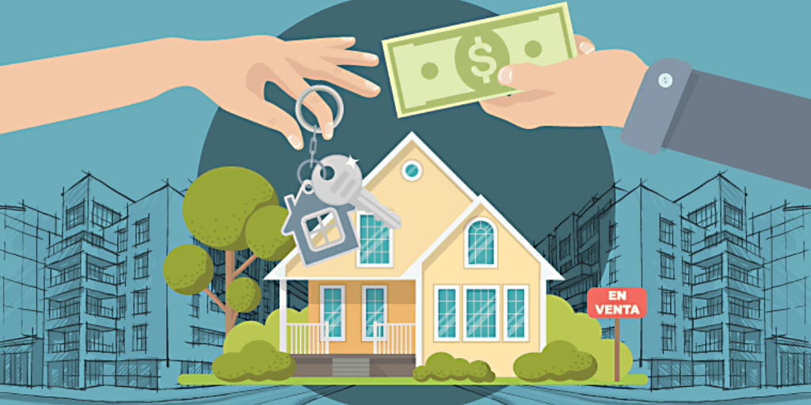

# 1. Introducción

La compra de vivienda es uno de los procesos financieros más importantes para los individuos y familias en todo el mundo. Para la mayoría de compradores, esta adquisición se realiza a través de un préstamo hipotecario, por lo que las instituciones financieras evalúan múltiples factores para determinar si un solicitante es elegible para un crédito y bajo qué condiciones.

El mercado inmobiliario global es un sector clave en la economía, moviendo miles de millones de dólares anualmente. La correcta evaluación del perfil financiero del comprador, junto con las características del inmueble, es fundamental tanto para garantizar el acceso a la vivienda como para reducir el riesgo económico de las entidades financieras.

## 1.1 Obtención de los datos

El set de datos fue obtenido de la plataforma Kaggle y contiene información global sobre compras de vivienda y decisiones de aprobación hipotecaria. Incluye 200,000 registros (muestras) con 25 variables relacionadas tanto con la propiedad como con el comprador y su historial financiero.

El objetivo principal de este estudio es realizar un análisis estadístico para comprender qué factores influyen en la aprobación o rechazo de un préstamo hipotecario. Asimismo, se buscará identificar qué características del comprador y de la propiedad tienen mayor peso en la decisión final y desarrollar modelos predictivos que permitan anticipar el resultado de aprobación crediticia.

## 1.2 Metodología

A lo largo de este trabajo, se pretenden analizar las siguientes preguntas:

- *¿Qué variables explican mejor el precio de una vivienda?*
  - ¿Influyen el país, tipo de propiedad, tamaño, número de habitaciones o el estado de mobiliario?
  - ¿Qué relación existe entre el precio y variables como el salario del comprador, el número de propietarios anteriores o el año de construcción?
- *¿Qué factores determinan la decisión de compra (variable decision)?*
  - ¿Qué peso tienen variables como el ratio EMI/income, el nivel de satisfacción (satisfaction_score), el rating del vecindario (neighbourhood_rating) o la conectividad (connectivity_score)?
  - ¿Se puede predecir la decisión de compra con un modelo de clasificación?
- *¿Existen diferencias significativas entre países o ciudades en cuanto a precios y decisiones de compra?*
  - ¿Qué países tienen precios más altos en promedio?
  - ¿Hay diferencias en la tasa de compra (decision = 1) entre regiones?
- *¿Cómo se distribuye el precio de las viviendas y hasta qué punto es posible predecirlo con modelos estadísticos y de machine learning?*
  - ¿Se ajusta a una distribución teórica conocida (gamma, log-normal, normal)?
  - ¿Qué modelo de regresión (lineal, regularizado o de machine learning) ofrece mejor rendimiento en la predicción del precio?
  - ¿Qué variables son más relevantes en la estimación?
- *¿Qué insights se pueden extraer sobre el perfil del comprador?*
  - ¿Qué relación hay entre salario, gastos mensuales, préstamo y decisión de compra?
  - ¿Influyen los aspectos legales (legal_cases_on_property) o de seguridad (crime_cases_reported)?

El análisis se llevará a cabo en dos fases principales:

### **Volumen 1: Análisis Exploratorio y Estadístico**

1. Importación de librerías y datos
2. Resumen estadístico general
3. Visualización de datos
4. Contraste de hipótesis y estadística inferencial
5. PCA: Análisis de Componentes Principales
   - Varianza explicada
   - Componentes principales

### **Volumen 2: Machine Learning**

6. Modelo para la decisión de compra (clasificación)
7. Modelo para el precio de la vivienda
8. Interpretación de resultados
9. Conclusiones y limitaciones
10. Referencias

## 1.3 Variables del dataset

El dataset incluye 200,000 registros con información sobre propiedades y compradores. En total hay 25 variables, pero a continuación se presentan las variables más relevantes:

- `price`: Precio de la vivienda
- `property_type`, `furnishing_status`: Tipo y nivel de amueblado
- `property_size_sqft`: Tamaño del inmueble
- `country`, `city`: Ubicación geográfica
- `customer_salary`: Salario anual del comprador
- `credit_score`: Puntaje crediticio
- `loan_amount`, `loan_tenure_years`: Monto y duración del préstamo
- `monthly_expenses`: Gastos mensuales
- `previous_loans`, `missed_payments`: Historial financiero
- `crime_cases_reported`: Seguridad del entorno
- `decision`: 1 = Compra aprobada, 0 = No compra

# 2. Análisis exploratorio de los datos

## 2.1 Importar datos y librerías

```r
library(dplyr)
library(ggplot2)
library(tidyr)
library(corrplot)
library(scales)
library(broom)
library(car)

data <- read.csv('./global_house_purchase_dataset.csv')
glimpse(data)
```

```
## Rows: 200,000
## Columns: 25
## $ property_id             <int> 1, 2, 3, 4, 5, 6, 7, 8, 9, 10, 11, 12, 13, 14,…
## $ country                 <chr> "France", "South Africa", "South Africa", "Ger…
## $ city                    <chr> "Marseille", "Cape Town", "Johannesburg", "Fra…
## $ property_type           <chr> "Farmhouse", "Apartment", "Farmhouse", "Farmho…
## $ furnishing_status       <chr> "Semi-Furnished", "Semi-Furnished", "Semi-Furn…
## $ property_size_sqft      <int> 991, 1244, 4152, 3714, 531, 3169, 1986, 4048, …
## $ price                   <int> 412935, 224538, 745104, 1110959, 99041, 110736…
## $ constructed_year        <int> 1989, 1990, 2019, 2008, 2007, 1985, 1976, 2020…
## $ previous_owners         <int> 6, 4, 5, 1, 6, 0, 1, 4, 6, 2, 4, 2, 4, 6, 6, 1…
## $ rooms                   <int> 6, 8, 2, 3, 3, 5, 2, 6, 2, 5, 8, 3, 2, 7, 3, 8…
## $ bathrooms               <int> 2, 8, 1, 3, 3, 2, 1, 6, 1, 2, 3, 1, 2, 2, 1, 6…
## $ garage                  <int> 1, 1, 1, 0, 1, 1, 1, 1, 0, 0, 0, 0, 0, 0, 1, 0…
## $ garden                  <int> 1, 1, 1, 1, 1, 0, 0, 1, 0, 1, 1, 0, 1, 1, 0, 1…
## $ crime_cases_reported    <int> 1, 1, 0, 0, 3, 0, 0, 1, 0, 0, 1, 4, 2, 6, 0, 1…
## $ legal_cases_on_property <int> 0, 1, 0, 0, 1, 0, 0, 0, 0, 1, 0, 1, 0, 0, 1, 1…
## $ customer_salary         <int> 10745, 16970, 21914, 17980, 17676, 95520, 1142…
## $ loan_amount             <int> 193949, 181465, 307953, 674720, 65833, 793316,…
## $ loan_tenure_years       <int> 15, 20, 30, 15, 25, 30, 25, 20, 15, 10, 25, 20…
## $ monthly_expenses        <int> 6545, 8605, 2510, 8805, 8965, 10615, 14440, 72…
## $ down_payment            <int> 218986, 43073, 437151, 436239, 33208, 314052, …
## $ emi_to_income_ratio     <dbl> 0.16, 0.08, 0.09, 0.33, 0.03, 0.05, 0.16, 0.13…
## $ satisfaction_score      <int> 1, 9, 6, 2, 3, 10, 9, 1, 8, 1, 8, 2, 3, 6, 1, …
## $ neighbourhood_rating    <int> 5, 1, 8, 6, 3, 8, 10, 5, 8, 4, 7, 5, 7, 9, 2, …
## $ connectivity_score      <int> 6, 2, 1, 6, 4, 2, 10, 8, 10, 7, 6, 6, 2, 1, 7,…
## $ decision                <int> 0, 0, 0, 0, 0, 1, 1, 0, 1, 0, 1, 0, 0, 0, 0, 0…
```

- ¿Hay valores faltantes? ¿Y duplicados?

```r
sum(is.na(data))
```

```
## [1] 0
```

```r
sum(duplicated(data))
```

```
## [1] 0
```

## 2.2 Resumen estadístico general

```r
data %>%
  select_if(is.numeric) %>%
  summary()
```

```
##   property_id     property_size_sqft     price         constructed_year
##  Min.   :     1   Min.   : 400       Min.   :  56288   Min.   :1960
##  1st Qu.: 50001   1st Qu.:1802       1st Qu.: 565990   1st Qu.:1975
##  Median :100001   Median :3190       Median :1023429   Median :1991
##  Mean   :100001   Mean   :3196       Mean   :1215365   Mean   :1991
##  3rd Qu.:150000   3rd Qu.:4589       3rd Qu.:1725556   3rd Qu.:2008
##  Max.   :200000   Max.   :6000       Max.   :4202732   Max.   :2023
##  previous_owners     rooms         bathrooms        garage
##  Min.   :0.000   Min.   :1.000   Min.   :1.00   Min.   :0.0000
##  1st Qu.:1.000   1st Qu.:3.000   1st Qu.:1.00   1st Qu.:0.0000
##  Median :3.000   Median :5.000   Median :2.00   Median :0.0000
##  Mean   :3.001   Mean   :4.514   Mean   :2.76   Mean   :0.4994
##  3rd Qu.:5.000   3rd Qu.:7.000   3rd Qu.:4.00   3rd Qu.:1.0000
##  Max.   :6.000   Max.   :8.000   Max.   :8.00   Max.   :1.0000
##      garden       crime_cases_reported legal_cases_on_property customer_salary
##  Min.   :0.0000   Min.   : 0.000       Min.   :0.0000          Min.   :  2000
##  1st Qu.:0.0000   1st Qu.: 0.000       1st Qu.:0.0000          1st Qu.: 21450
##  Median :1.0000   Median : 1.000       Median :0.0000          Median : 41465
##  Mean   :0.5002   Mean   : 1.229       Mean   :0.2489          Mean   : 46529
##  3rd Qu.:1.0000   3rd Qu.: 2.000       3rd Qu.:0.0000          3rd Qu.: 70805
##  Max.   :1.0000   Max.   :10.000       Max.   :1.0000          Max.   :100000
##   loan_amount      loan_tenure_years monthly_expenses  down_payment
##  Min.   :  23504   Min.   :10.00     Min.   :  500    Min.   :   8966
##  1st Qu.: 337280   1st Qu.:15.00     1st Qu.: 5770    1st Qu.: 184959
##  Median : 626932   Median :20.00     Median :10520    Median : 356170
##  Mean   : 759758   Mean   :19.99     Mean   :10560    Mean   : 455607
##  3rd Qu.:1058416   3rd Qu.:25.00     3rd Qu.:15260    3rd Qu.: 625735
##  Max.   :3520150   Max.   :30.00     Max.   :20000    Max.   :2492723
##  emi_to_income_ratio satisfaction_score neighbourhood_rating connectivity_score
##  Min.   :0.0000      Min.   : 1.000     Min.   : 1.000       Min.   : 1.000
##  1st Qu.:0.0700      1st Qu.: 3.000     1st Qu.: 3.000       1st Qu.: 3.000
##  Median :0.1300      Median : 5.000     Median : 5.000       Median : 5.000
##  Mean   :0.1954      Mean   : 5.499     Mean   : 5.505       Mean   : 5.496
##  3rd Qu.:0.2400      3rd Qu.: 8.000     3rd Qu.: 8.000       3rd Qu.: 8.000
##  Max.   :3.4600      Max.   :10.000     Max.   :10.000       Max.   :10.000
##     decision
##  Min.   :0.0000
##  1st Qu.:0.0000
##  Median :0.0000
##  Mean   :0.2303
##  3rd Qu.:0.0000
##  Max.   :1.0000
```

```r
sapply(data %>% select(where(is.character)), n_distinct)
```

```
##           country              city     property_type furnishing_status
##                13                40                 6                 3
```

## 2.3 Visualización de datos

### **Distribución de la variable `decision`**

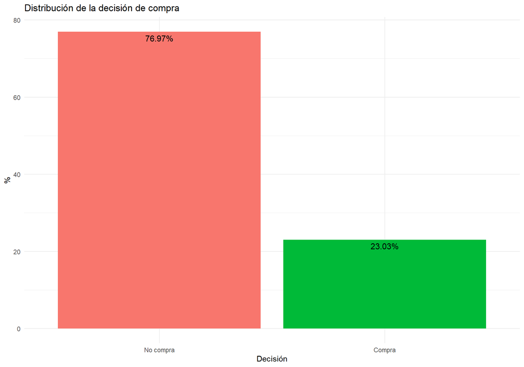

```r
data %>%
  count(decision) %>%
  mutate(pct = n/sum(n)*100,
         decision = factor(decision, labels = c("No compra", "Compra"))) %>%
  ggplot(aes(x = decision, y = pct, fill = decision)) +
  geom_col() +
  geom_text(aes(label = sprintf("%.2f%%", pct)),
            vjust = 1.5, color = "black", size = 4) +
  labs(title = "Distribución de la decisión de compra",
       x = "Decisión", y = "%") +
  scale_fill_manual(values = c("#F8766D", "#00BA38")) +
  theme_minimal() +
  theme(legend.position = "none")
```

### **Distribución del precio**

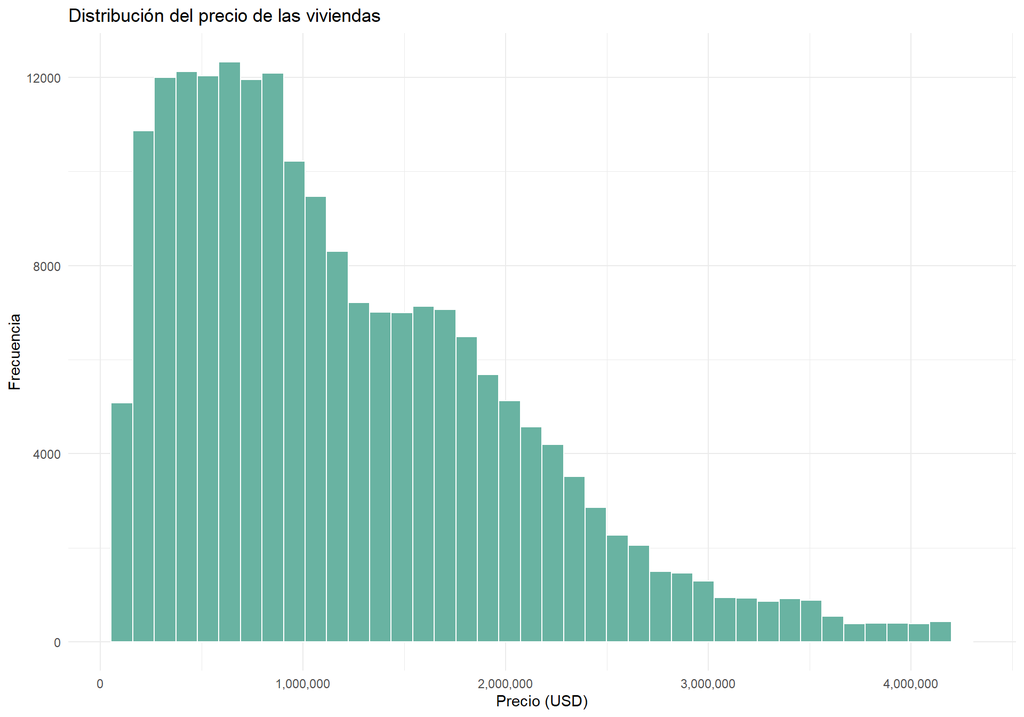

```r
ggplot(data, aes(x = price)) +
  geom_histogram(fill = "#69b3a2", color = "white", bins = 40) +
  scale_x_continuous(labels = comma) +
  labs(title = "Distribución del precio de las viviendas",
  x = "Precio (USD)", y = "Frecuencia") +
  theme_minimal()
```

En este histograma podemos ver cómo el precio sigue una distribución parecida a una gamma. Ahora vamos a ver si aplicando una transformación logarítmica, obtenemos una distribución más parecida a una normal.

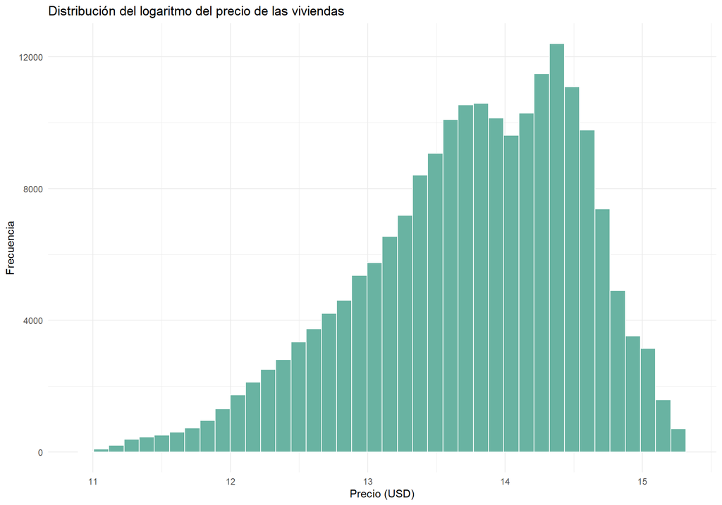

```r
data <- data %>% mutate(log_price = log(price))

ggplot(data, aes(x = log_price)) +
  geom_histogram(fill = "#69b3a2", color = "white", bins = 40) +
  scale_x_continuous() +
  labs(title = "Distribución del logaritmo del precio de las viviendas",
  x = "Precio (USD)", y = "Frecuencia") +
  theme_minimal()
```

### **Distribución del precio por país y por tipo de propiedad**

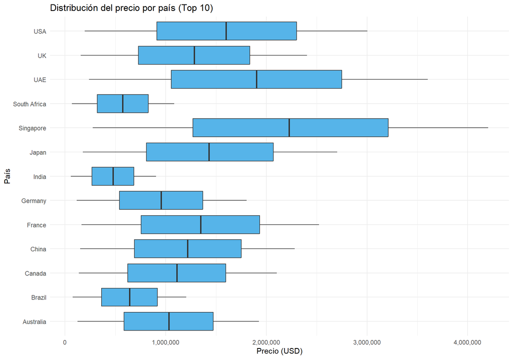

```r
# Boxplot de precios por país
data %>%
  ggplot(aes(x = country, y = price)) +
  geom_boxplot(fill = "#56B4E9", outlier.alpha = 0.2) +
  coord_flip() +
  scale_y_continuous(labels = comma) +
  labs(title = "Distribución del precio por país (Top 10)",
       x = "País", y = "Precio (USD)") +
  theme_minimal()
```

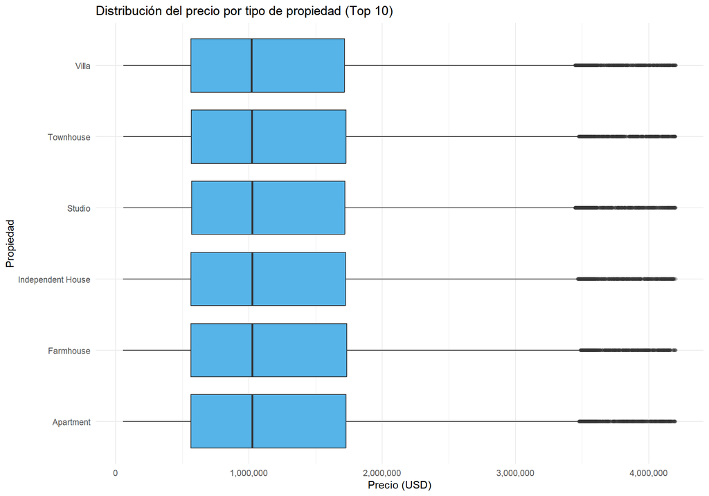

```r
# Boxplot de precios por tipo de propiedad

data %>%
  ggplot(aes(x = property_type, y = price)) +
  geom_boxplot(fill = "#56B4E9", outlier.alpha = 0.2) +
  scale_y_continuous(labels = comma) +
  coord_flip() +
  labs(title = "Distribución del precio por tipo de propiedad (Top 10)",
       x = "Propiedad", y = "Precio (USD)") +
  theme_minimal()
```

### **Relaciones entre variables numéricas**

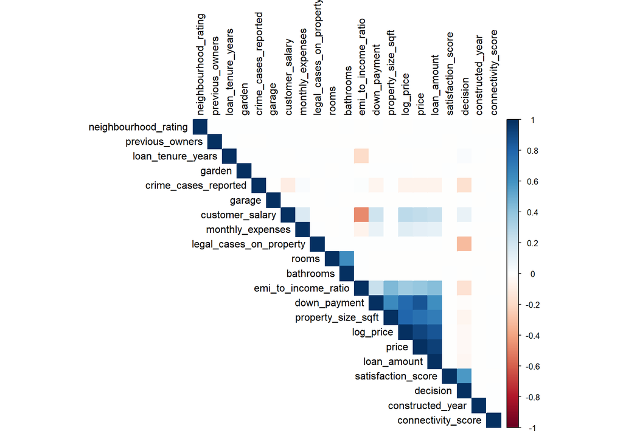

```r
# Seleccionar variables numéricas relevantes

num_vars <- data %>%
  select_if(is.numeric) %>%
  select(-property_id)

# Matriz de correlación

corr_matrix <- cor(num_vars)

corrplot(corr_matrix, method = "color", type = "upper", tl.col = "black", order = "hclust")
```

### **Relaciones bivariantes**

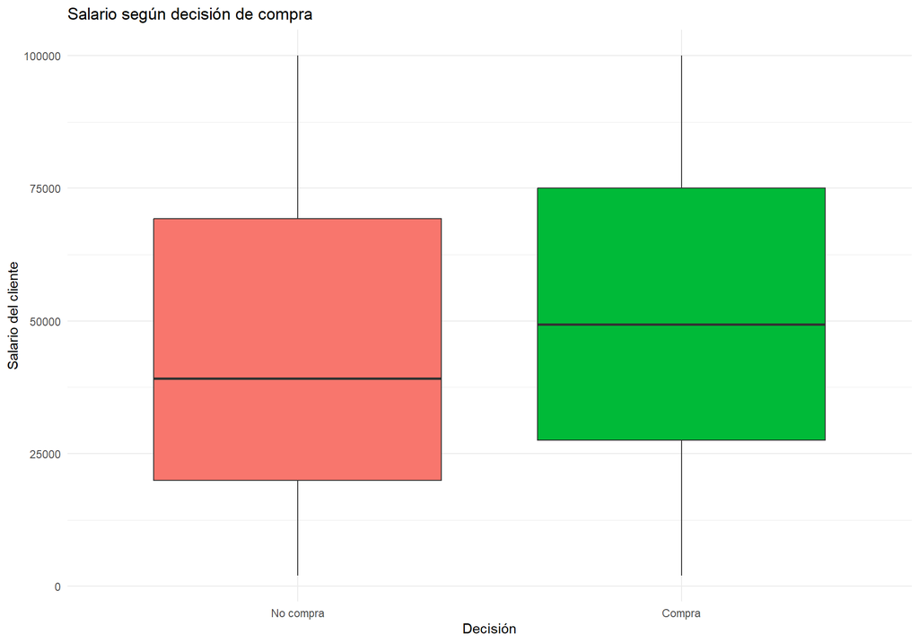

```r
# Salario vs Decisión de compra
data %>%
  mutate(decision = factor(decision, labels = c("No compra", "Compra"))) %>%
  ggplot(aes(x = decision, y = customer_salary, fill = decision)) +
  geom_boxplot(outlier.alpha = 0.2) +
  scale_fill_manual(values = c("#F8766D", "#00BA38")) +
  labs(title = "Salario según decisión de compra",
  x = "Decisión", y = "Salario del cliente") +
  theme_minimal() +
  theme(legend.position = "none")
```

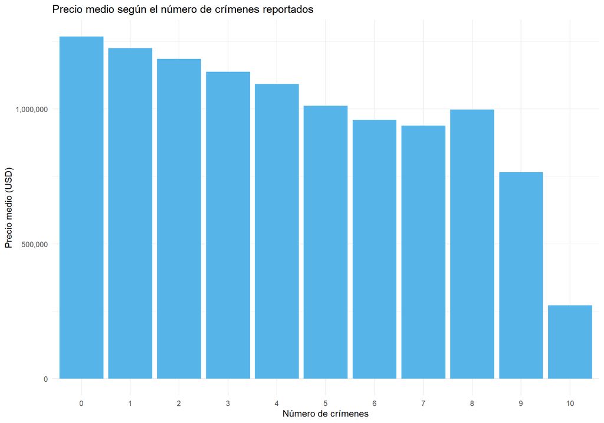

```r
# Número de crímenes reportados vs Precio medio
data %>%
  group_by(crime_cases_reported) %>%
  summarise(mean_price = mean(price, na.rm = TRUE)) %>%
  ggplot(aes(x = factor(crime_cases_reported), y = mean_price)) +
  geom_col(fill = "#56B4E9") +
  scale_y_continuous(labels = comma) +
  labs(title = "Precio medio según el número de crímenes reportados",
  x = "Número de crímenes", y = "Precio medio (USD)") +
  theme_minimal()
```

### **Decisión de compra por país**

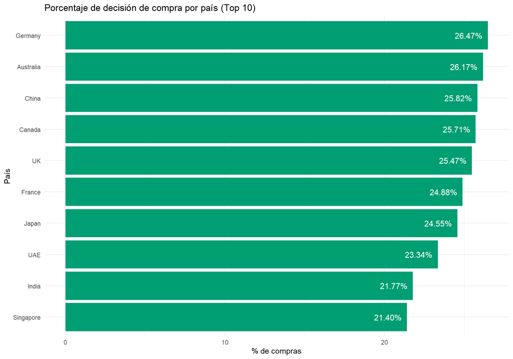

```r
# ¿Qué porcentaje de personas toma la decisión de comprar una vivienda en cada país?
data %>%
  group_by(country) %>%
  summarise(pct_purchase = mean(decision) * 100) %>%
  arrange(desc(pct_purchase)) %>%
  slice_head(n = 10) %>%
  ggplot(aes(x = reorder(country, pct_purchase), y = pct_purchase)) +
  geom_col(fill = "#009E73") +
  geom_text(aes(label = sprintf("%.2f%%", pct_purchase)),
            hjust = 1.2, color = "white", size = 4) +
  coord_flip() +
  labs(title = "Porcentaje de decisión de compra por país (Top 10)",
  x = "País", y = "% de compras") +
  theme_minimal()
```

# 3. Contraste de hipótesis y estadística inferencial

En esta sección se pretende verificar estadísticamente algunas de las relaciones sugeridas en el análisis exploratorio previo. Para ello, se formulan hipótesis estadísticas y se aplican pruebas de contraste adecuadas según el tipo de variable y la distribución observada.

## 3.1 Diferencias de precio entre países

Hipótesis:

- H0: El precio medio es igual entre los países.
- H1: Al menos un país presenta un precio medio distinto.

```r
# Test de normalidad
shapiro.test(sample(data$log_price, 5000))
```

```
##
##  Shapiro-Wilk normality test
##
## data:  sample(data$log_price, 5000)
## W = 0.97162, p-value < 2.2e-16
```

El test de Shapiro-Wilk aplicado a una muestra aleatoria de log(price) muestra un p-value < 2.2e-16, indicando que la variable transformada no sigue una distribución normal perfecta. Sin embargo, dado el gran tamaño muestral, el ANOVA es robusto frente a desviaciones de normalidad.

A continuación, se realiza la prueba de Levene para ver si las varianzas entre países son homogéneas o no, y esto nos indicará si podemos utilizar el test paramétrico de ANOVA o, en caso contrario, el de Kruskal-Wallis.

```r
# Test de homogeneidad de varianzas
leveneTest(log_price ~ factor(country), data = data)
```

```
## Levene's Test for Homogeneity of Variance (center = median)
##           Df F value Pr(>F)
## group     12  1.4727  0.126
##       199987
```

Antes de realizar el contraste de medias entre países, se evaluó la homogeneidad de varianzas mediante el test de Levene sobre log(price). El resultado (p = 0.126) indica que no existe evidencia suficiente para rechazar la igualdad de varianzas, por lo que se cumple el supuesto de homocedasticidad. Por ello, se aplicó un ANOVA clásico para comparar el precio medio entre países usando la variable transformada.

```r
# ANOVA
anova_country <- aov(log_price ~ factor(country), data = data)
summary(anova_country)
```

```
##                     Df Sum Sq Mean Sq F value Pr(>F)
## factor(country)     12  38869    3239    7414 <2e-16 ***
## Residuals       199987  87373       0
## ---
## Signif. codes:  0 '***' 0.001 '**' 0.01 '*' 0.05 '.' 0.1 ' ' 1
```

El ANOVA resultó significativo (p < 2e-16), lo que indica diferencias en los precios medios entre países. Posteriormente, se realizó el test de Tukey para ver qué países difieren entre sí en el precio medio.

Este test de Tukey incluye una corrección automática del error familiar (FWER), garantizando que la probabilidad de obtener falsos positivos se mantenga controlada al realizar múltiples comparaciones simultáneas.

```r
# Post-hoc Tukey
tukey <- TukeyHSD(anova_country)
sum(tukey[["factor(country)"]][, "p adj"]>0.05)
```

```
## [1] 0
```

El test post-hoc de Tukey mostró diferencias significativas entre todos los pares de países (p < 0.001), confirmando que el país de localización es un factor determinante en el precio de la vivienda.

## 3.2 Factores que influyen en la decisión de compra

```r
data$decision <- as.factor(data$decision)

model1 <- glm(decision ~ log_price + factor(country) +
                satisfaction_score + bathrooms + rooms +
                previous_owners, data
              = data, family = binomial)

summary(model1)
```

```
##
## Call:
## glm(formula = decision ~ log_price + factor(country) + satisfaction_score +
##     bathrooms + rooms + previous_owners, family = binomial, data = data)
##
## Coefficients:
##                               Estimate Std. Error z value Pr(>|z|)
## (Intercept)                 -2.071e+00  1.445e-01 -14.338  < 2e-16 ***
## log_price                   -3.119e-01  1.035e-02 -30.145  < 2e-16 ***
## factor(country)Brazil       -9.601e-01  3.608e-02 -26.608  < 2e-16 ***
## factor(country)Canada       -2.306e-02  3.437e-02  -0.671   0.5024
## factor(country)China        -7.392e-03  3.430e-02  -0.215   0.8294
## factor(country)France       -2.761e-02  3.441e-02  -0.802   0.4223
## factor(country)Germany      -8.422e-03  3.427e-02  -0.246   0.8059
## factor(country)India        -6.797e-01  3.579e-02 -18.992  < 2e-16 ***
## factor(country)Japan        -6.311e-02  3.464e-02  -1.822   0.0684 .
## factor(country)Singapore    -2.200e-01  3.584e-02  -6.138 8.38e-10 ***
## factor(country)South Africa -9.945e-01  3.616e-02 -27.505  < 2e-16 ***
## factor(country)UAE          -1.008e-01  3.529e-02  -2.855   0.0043 **
## factor(country)UK            2.721e-03  3.440e-02   0.079   0.9369
## factor(country)USA          -6.912e-01  3.606e-02 -19.166  < 2e-16 ***
## satisfaction_score           7.879e-01  3.956e-03 199.167  < 2e-16 ***
## bathrooms                   -3.584e-03  4.799e-03  -0.747   0.4551
## rooms                        3.335e-05  3.849e-03   0.009   0.9931
## previous_owners              4.900e-03  3.441e-03   1.424   0.1544
## ---
## Signif. codes:  0 '***' 0.001 '**' 0.01 '*' 0.05 '.' 0.1 ' ' 1
##
## (Dispersion parameter for binomial family taken to be 1)
##
##     Null deviance: 215875  on 199999  degrees of freedom
## Residual deviance: 131859  on 199982  degrees of freedom
## AIC: 131895
##
## Number of Fisher Scoring iterations: 6
```

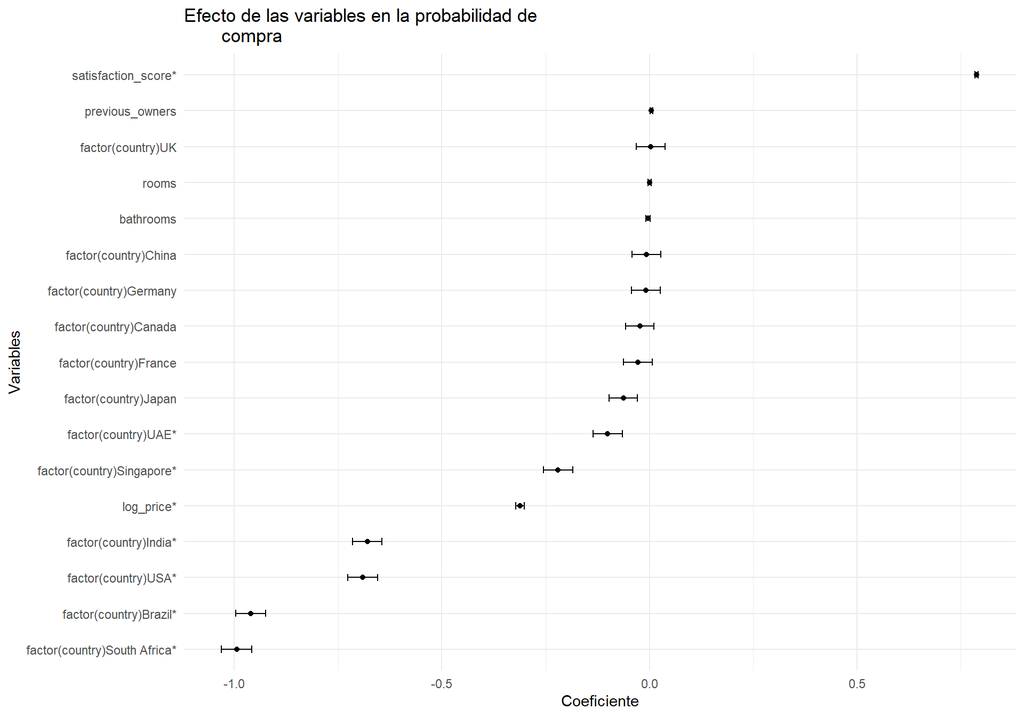

```r
coef_plot <- tidy(model1) %>%
  filter(term != "(Intercept)") %>%
  mutate(signif = ifelse(p.value < 0.05, "*", ""),
         term = paste0(term, signif),
         term = reorder(term, estimate))

ggplot(coef_plot, aes(x = term, y = estimate)) +
  geom_point() +
  geom_errorbar(aes(ymin = estimate - std.error, ymax =
                      estimate + std.error),
                width = 0.2) +
  coord_flip() +
  theme_minimal() +
  labs(title = "Efecto de las variables en la probabilidad de
       compra",
       x = "Variables", y = "Coeficiente")
```

El modelo de regresión logística muestra que la decisión de compra está influida principalmente por el precio de la vivienda (en su escala logarítmica), el país donde se ubica el inmueble y el nivel de satisfacción del comprador. En particular, se observa que el coeficiente de log_price es negativo y altamente significativo (p < .001), indicando que a medida que el precio aumenta, la probabilidad de que el comprador decida adquirir la vivienda disminuye. Esto sugiere que la capacidad económica es un factor limitante importante en la decisión.

La variable satisfaction_score presenta un efecto positivo y muy significativo (p < .001), lo que implica que un mayor nivel de satisfacción subjetiva aumenta notablemente la probabilidad de compra. Este resultado destaca el papel de la percepción personal y la valoración emocional del inmueble en la toma de decisiones, no solo factores económicos.

También se identifican diferencias significativas entre países: compradores en Brasil, India, Sudáfrica, Singapur, Emiratos Árabes Unidos y Estados Unidos muestran probabilidades significativamente diferentes de compra respecto al país de referencia (Australia, por defecto). Esto sugiere que existen diferencias culturales, regulatorias o económicas entre mercados inmobiliarios internacionales que influyen en la decisión de compra.

Por el contrario, variables relacionadas con características físicas del inmueble, como el número de habitaciones (rooms), el número de baños (bathrooms) y el número de propietarios anteriores (previous_owners), no muestran efectos significativos en la decisión de compra cuando se controlan el resto de factores. Esto indica que, en este contexto, las características estructurales parecen tener un papel menos determinante que la satisfacción percibida y el precio relativo.

# 4. PCA: Análisis de Componentes Principales